# M505D_Intro_to_AI_and_Machine_Learning_WinThidaTun (1)

## Introduction

Obesity is a major global health issue that has effects on both physical and mental health. New research that looks at the elements that contribute to obesity and how to forecast the condition based on these factors is necessary because the prevalence of obesity is continually rising. This dataset contains information for estimating the prevalence of obesity in people from Mexico, Peru, and Colombia based on their physical characteristics and eating patterns. The records are labeled with the class variable NObesity (Obesity Level), which enables the data to be classified using the following values: Normal Weight, Insufficient Weight, Obesity Type I, Obesity Type II, Obesity Type III, and Overweight Level I and II.

## Attribute Information

*Features*

1. Gender - male or female
2. Age
3. Weight(kg)
4. Height(m)
5. family_history_with_overweight
6. FAVC: High Caloric Food intake
7. FCVC : Vegetable intake
8. NCP : Number of main meal intake
9. CAEC : Snacking behavior
10. SMOKE : Smoking
11. CH2O : Daily water intake
12. SCC : Daily monitor calories intake
13. FAF : physical activity
14. TUE : Tech usage (hrs)
15. CALC : Alcohol intake
16. MTRANS : Mode of transportations

*Target Label*

17. NObeyesdad (Obesity Level)
- Underweight Less than 18.5
- Normal 18.5 to 24.9
- Overweight 25.0 to 29.9
- Obesity I 30.0 to 34.9
- Obesity II 35.0 to 39.9
- Obesity III Higher than 40

Original Source : https://archive.ics.uci.edu/dataset/544/estimation+of+obesity+levels+based+on+eating+habits+and+physical+condition

# Problem Statement /Objective

I worked at a Start-up company and I have been assigned to create a mechine learning model to predict the possibilities of obesities level based on known data ( level data) by inputing the physical attributies and nutritation intake. So, that my company can build the app to predict the customers/patients' possibilites of the becoming obeses. This will help customers/patients to have preventation/ diet on early stages or take the medication/treatment plan immediately.

This model will be use 'Accuracy' as the primary tool to evaluate the model.

## Importing Libaries

```python
import pandas as pd
import numpy as np
import seaborn as sns
import matplotlib.pyplot as plt
from prettytable import PrettyTable

import sklearn.compose
from sklearn.preprocessing import LabelEncoder, StandardScaler
from sklearn.model_selection import train_test_split
from sklearn.linear_model import LogisticRegression
from sklearn.svm import SVC
from sklearn.tree import DecisionTreeClassifier
from sklearn.metrics import confusion_matrix, classification_report, accuracy_score
```

## Data Collection

```python
df_org = pd.read_csv('/content/ObesityDataSet_raw_and_data_sinthetic.csv')
```

```python
df_org.shape
```

```
(2111, 17)
```

```python
df_org.head(10)
```

|  | Gender | Age | Height | Weight | family_history_with_overweight | FAVC | FCVC | NCP | CAEC | SMOKE | CH2O | SCC | FAF | TUE | CALC | MTRANS | NObeyesdad |
| --- | --- | --- | --- | --- | --- | --- | --- | --- | --- | --- | --- | --- | --- | --- | --- | --- | --- |
| 0 | Female | 21.0 | 1.62 | 64.0 | yes | no | 2.0 | 3.0 | Sometimes | no | 2.0 | no | 0.0 | 1.0 | no | Public_Transportation | Normal_Weight |
| 1 | Female | 21.0 | 1.52 | 56.0 | yes | no | 3.0 | 3.0 | Sometimes | yes | 3.0 | yes | 3.0 | 0.0 | Sometimes | Public_Transportation | Normal_Weight |
| 2 | Male | 23.0 | 1.80 | 77.0 | yes | no | 2.0 | 3.0 | Sometimes | no | 2.0 | no | 2.0 | 1.0 | Frequently | Public_Transportation | Normal_Weight |
| 3 | Male | 27.0 | 1.80 | 87.0 | no | no | 3.0 | 3.0 | Sometimes | no | 2.0 | no | 2.0 | 0.0 | Frequently | Walking | Overweight_Level_I |
| 4 | Male | 22.0 | 1.78 | 89.8 | no | no | 2.0 | 1.0 | Sometimes | no | 2.0 | no | 0.0 | 0.0 | Sometimes | Public_Transportation | Overweight_Level_II |
| 5 | Male | 29.0 | 1.62 | 53.0 | no | yes | 2.0 | 3.0 | Sometimes | no | 2.0 | no | 0.0 | 0.0 | Sometimes | Automobile | Normal_Weight |
| 6 | Female | 23.0 | 1.50 | 55.0 | yes | yes | 3.0 | 3.0 | Sometimes | no | 2.0 | no | 1.0 | 0.0 | Sometimes | Motorbike | Normal_Weight |
| 7 | Male | 22.0 | 1.64 | 53.0 | no | no | 2.0 | 3.0 | Sometimes | no | 2.0 | no | 3.0 | 0.0 | Sometimes | Public_Transportation | Normal_Weight |
| 8 | Male | 24.0 | 1.78 | 64.0 | yes | yes | 3.0 | 3.0 | Sometimes | no | 2.0 | no | 1.0 | 1.0 | Frequently | Public_Transportation | Normal_Weight |
| 9 | Male | 22.0 | 1.72 | 68.0 | yes | yes | 2.0 | 3.0 | Sometimes | no | 2.0 | no | 1.0 | 1.0 | no | Public_Transportation | Normal_Weight |

```python
df_org.info()
```

```
<class 'pandas.core.frame.DataFrame'>
RangeIndex: 2111 entries, 0 to 2110
Data columns (total 17 columns):
 #   Column                          Non-Null Count  Dtype
---  ------                          --------------  -----
 0   Gender                          2111 non-null   object
 1   Age                             2111 non-null   float64
 2   Height                          2111 non-null   float64
 3   Weight                          2111 non-null   float64
 4   family_history_with_overweight  2111 non-null   object
 5   FAVC                            2111 non-null   object
 6   FCVC                            2111 non-null   float64
 7   NCP                             2111 non-null   float64
 8   CAEC                            2111 non-null   object
 9   SMOKE                           2111 non-null   object
 10  CH2O                            2111 non-null   float64
 11  SCC                             2111 non-null   object
 12  FAF                             2111 non-null   float64
 13  TUE                             2111 non-null   float64
 14  CALC                            2111 non-null   object
 15  MTRANS                          2111 non-null   object
 16  NObeyesdad                      2111 non-null   object
dtypes: float64(8), object(9)
memory usage: 280.5+ KB
```

```python
df = df_org.copy()
```

## Data Preprocessing

**Checking Missing Data**

```python
print(df.duplicated().sum())
```

```
24
```

```python
df = df.drop_duplicates()
```

Dropping the duplicates

```python
df.shape
```

```
(2087, 17)
```

```python
if df.isna().sum().sum() == 0:
  print('The Dataset is clean.')
```

```
The Dataset is clean.
```

Since there are no missing data, we are going to proceed into next step.

**Renaming columns for better understanding**

```python
df = df.rename(columns={'family_history_with_overweight':'Family_Obesity_History',
                        'FAVC':'High_Caloric_Food',
                        'FCVC':'Vege_Intake',
                        'NCP':'Num_of_MainMeal_intake',
                        'CAEC':'Snacking_Behavior',
                        'CH2O':'Water_intake',
                        'SCC': 'Monitor_Calories',
                        'FAF': 'PhysicalActivity',
                        'TUE': 'Tech_Usage',
                        'CALC': 'Alcohol_intake',
                        'MTRANS': 'Transportations',
                        'NObeyesdad': 'Obesity_Level'})
```

**Splitting data into Train/Test**

```python
df_train, df_test = train_test_split(df)
```

```python
print('df.size:', df.size)
print('df_train.size:', df_train.size)
print('df_test.size:', df_test.size)
```

```
df.size: 35479
df_train.size: 26605
df_test.size: 8874
```

```python
print('df.shape:', df.shape)
print('df_train.shape:', df_train.shape)
print('df_test.shape:', df_test.shape)
```

```
df.shape: (2087, 17)
df_train.shape: (1565, 17)
df_test.shape: (522, 17)
```

## Data Exploration

```python
df_train.dtypes
```

|  | 0 |
| --- | --- |
| Gender | object |
| Age | float64 |
| Height | float64 |
| Weight | float64 |
| Family_Obesity_History | object |
| High_Caloric_Food | object |
| Vege_Intake | float64 |
| Num_of_MainMeal_intake | float64 |
| Snacking_Behavior | object |
| SMOKE | object |
| Water_intake | float64 |
| Monitor_Calories | object |
| PhysicalActivity | float64 |
| Tech_Usage | float64 |
| Alcohol_intake | object |
| Transportations | object |
| Obesity_Level | object |

**dtype:** object

```python
df.info()
```

```
<class 'pandas.core.frame.DataFrame'>
Index: 2087 entries, 0 to 2110
Data columns (total 17 columns):
 #   Column                  Non-Null Count  Dtype
---  ------                  --------------  -----
 0   Gender                  2087 non-null   object
 1   Age                     2087 non-null   float64
 2   Height                  2087 non-null   float64
 3   Weight                  2087 non-null   float64
 4   Family_Obesity_History  2087 non-null   object
 5   High_Caloric_Food       2087 non-null   object
 6   Vege_Intake             2087 non-null   float64
 7   Num_of_MainMeal_intake  2087 non-null   float64
 8   Snacking_Behavior       2087 non-null   object
 9   SMOKE                   2087 non-null   object
 10  Water_intake            2087 non-null   float64
 11  Monitor_Calories        2087 non-null   object
 12  PhysicalActivity        2087 non-null   float64
 13  Tech_Usage              2087 non-null   float64
 14  Alcohol_intake          2087 non-null   object
 15  Transportations         2087 non-null   object
 16  Obesity_Level           2087 non-null   object
dtypes: float64(8), object(9)
memory usage: 293.5+ KB
```

```python
df_train.head(10)
```

|  | Gender | Age | Height | Weight | Family_Obesity_History | High_Caloric_Food | Vege_Intake | Num_of_MainMeal_intake | Snacking_Behavior | SMOKE | Water_intake | Monitor_Calories | PhysicalActivity | Tech_Usage | Alcohol_intake | Transportations | Obesity_Level |
| --- | --- | --- | --- | --- | --- | --- | --- | --- | --- | --- | --- | --- | --- | --- | --- | --- | --- |
| 165 | Male | 30.000000 | 1.920000 | 130.000000 | yes | no | 2.000000 | 3.000000 | Sometimes | yes | 1.000000 | no | 1.000000 | 0.000000 | Sometimes | Public_Transportation | Obesity_Type_II |
| 1790 | Male | 23.147644 | 1.815514 | 120.337664 | yes | yes | 2.996717 | 2.791366 | Sometimes | no | 2.626309 | no | 1.194898 | 0.034897 | Sometimes | Public_Transportation | Obesity_Type_II |
| 76 | Female | 24.000000 | 1.600000 | 45.000000 | yes | no | 2.000000 | 3.000000 | no | no | 2.000000 | no | 1.000000 | 0.000000 | no | Public_Transportation | Insufficient_Weight |
| 202 | Female | 26.000000 | 1.560000 | 102.000000 | yes | yes | 3.000000 | 3.000000 | Sometimes | yes | 1.000000 | no | 0.000000 | 1.000000 | Sometimes | Public_Transportation | Obesity_Type_III |
| 604 | Female | 19.000000 | 1.538398 | 42.000000 | no | yes | 2.718970 | 1.473088 | Frequently | no | 1.164644 | no | 1.235675 | 0.930926 | Sometimes | Public_Transportation | Insufficient_Weight |
| 1496 | Male | 28.421533 | 1.829239 | 107.108190 | yes | yes | 2.465575 | 2.935381 | Sometimes | no | 2.480555 | no | 1.001830 | 1.670313 | Sometimes | Automobile | Obesity_Type_I |
| 1252 | Male | 23.000000 | 1.791415 | 105.138073 | yes | yes | 2.262171 | 3.000000 | Sometimes | no | 2.034150 | no | 0.317363 | 0.508663 | Sometimes | Public_Transportation | Obesity_Type_I |
| 614 | Female | 20.971429 | 1.549311 | 41.557468 | no | yes | 2.927218 | 1.000000 | Frequently | no | 1.000000 | no | 0.000000 | 0.276592 | Sometimes | Public_Transportation | Insufficient_Weight |
| 546 | Female | 19.058511 | 1.662017 | 49.838965 | no | yes | 1.492500 | 3.000000 | Sometimes | no | 1.049134 | no | 2.000000 | 1.000000 | Sometimes | Public_Transportation | Insufficient_Weight |
| 1931 | Female | 25.748627 | 1.668770 | 104.774144 | yes | yes | 3.000000 | 3.000000 | Sometimes | no | 1.526416 | no | 0.180158 | 0.747909 | Sometimes | Public_Transportation | Obesity_Type_III |

```python
df_train.describe().T
```

|  | count | mean | std | min | 25% | 50% | 75% | max |
| --- | --- | --- | --- | --- | --- | --- | --- | --- |
| Age | 1565.0 | 24.429207 | 6.430150 | 15.00 | 20.000000 | 22.875223 | 26.000000 | 61.000000 |
| Height | 1565.0 | 1.701736 | 0.092452 | 1.45 | 1.630730 | 1.700740 | 1.767121 | 1.931263 |
| Weight | 1565.0 | 87.068014 | 26.139339 | 39.00 | 66.500000 | 84.000000 | 107.947470 | 160.935351 |
| Vege_Intake | 1565.0 | 2.426396 | 0.539211 | 1.00 | 2.000000 | 2.432355 | 3.000000 | 3.000000 |
| Num_of_MainMeal_intake | 1565.0 | 2.690921 | 0.769364 | 1.00 | 2.655265 | 3.000000 | 3.000000 | 4.000000 |
| Water_intake | 1565.0 | 2.002699 | 0.607140 | 1.00 | 1.601140 | 2.000000 | 2.451260 | 3.000000 |
| PhysicalActivity | 1565.0 | 1.012701 | 0.850505 | 0.00 | 0.131371 | 1.000000 | 1.668961 | 3.000000 |
| Tech_Usage | 1565.0 | 0.656797 | 0.604806 | 0.00 | 0.000000 | 0.629285 | 1.000000 | 2.000000 |

Average age of participant is 24 years old and the higest standard deviation is weight with 26.

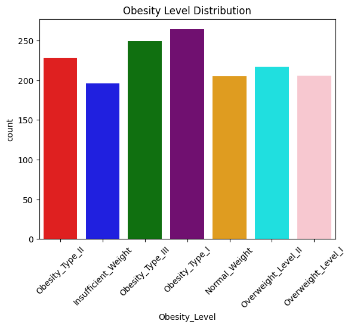

```python
colors = ['red', 'blue', 'green', 'purple', 'orange', 'cyan', 'pink']
sns.countplot(x= 'Obesity_Level', data = df_train, palette=colors, hue= 'Obesity_Level', legend=False)
plt.xticks(rotation=45)
plt.title('Obesity Level Distribution')
plt.show()
```

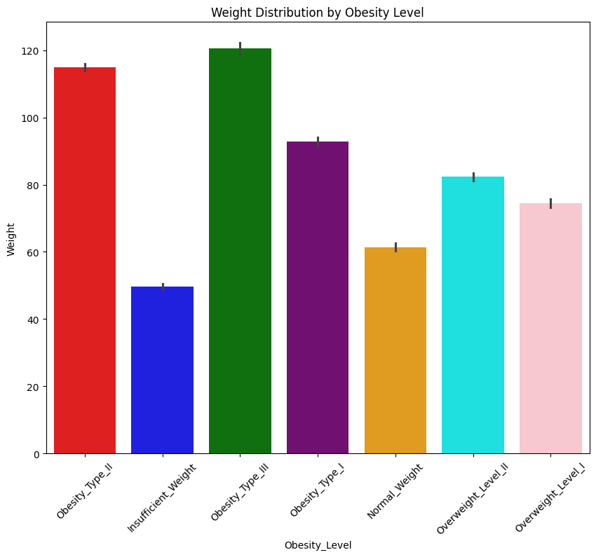

```python
plt.figure(figsize=(10, 8))
sns.barplot(x='Obesity_Level', y='Weight', data=df_train, hue = 'Obesity_Level', legend=False,  palette=colors)
plt.title('Weight Distribution by Obesity Level')
plt.xticks(rotation=45)
plt.show()
```

```python
df_train.corr()['Obesity_Level']
```

[output not shown]

**dtype:** float64

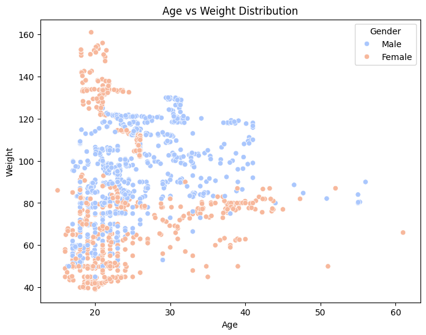

```python
plt.figure(figsize=(8, 6))
sns.scatterplot(x='Age', y='Weight', data=df_train, hue='Gender', palette='coolwarm')
plt.title('Age vs Weight Distribution')
plt.xlabel('Age')
plt.ylabel('Weight')
plt.show()
```

The level of intense weight is frequent in the age 20s especially female participant.

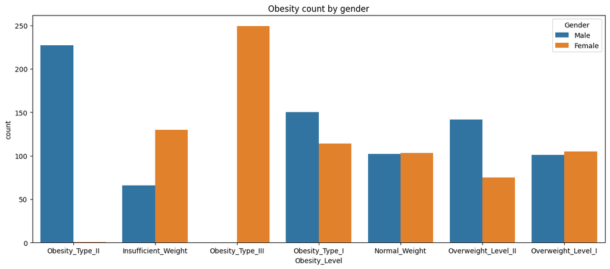

```python
plt.figure(figsize= (15, 6))
sns.countplot(data= df_train, x='Obesity_Level', hue='Gender')
plt.title('Obesity count by gender')
plt.show()
```

The higher obesity type of male is in obesity type 2 and for female, obesity type 3 is highest.

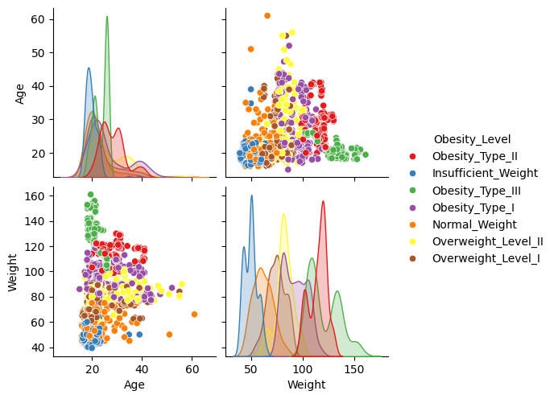

```python
sns.pairplot(data = df_train, vars=['Age', 'Weight'], hue='Obesity_Level', palette='Set1')
plt.show()
```

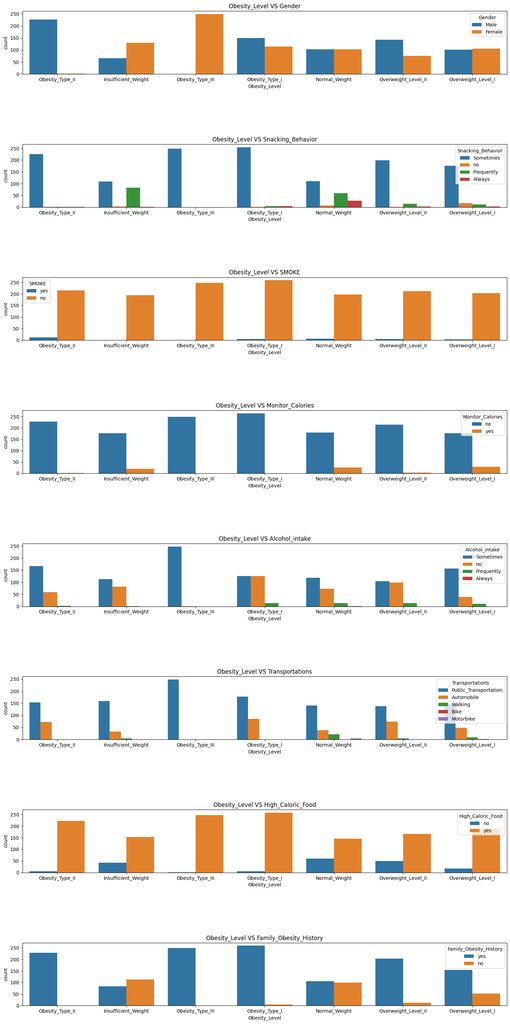

```python
cat_cols = ['Gender','Snacking_Behavior', 'SMOKE','Monitor_Calories','Alcohol_intake', 'Transportations','High_Caloric_Food','Family_Obesity_History']
fig, ax = plt.subplots(nrows = 8, figsize = (15, 30))
i = 0
for col in cat_cols :
    sns.countplot(data = df_train, x =  'Obesity_Level', hue = col, ax = ax[i])
    ax[i].set_title(f'Obesity_Level VS {col}')
    i += 1
fig.tight_layout(h_pad = 10)
plt.show();
```

Overall, As per above analysis, the weight and family history of having obesity are is directly correlated with the chance of having obesity. On the other hand, smoking and drinking alcohol are not depended on having obesity. Unsurprisingly, having physical activities can reduce the risk of obesitiy.

## Feature Enginering

```python
label_encoder = LabelEncoder()
categorical_columns = ['Gender','Snacking_Behavior', 'SMOKE','Monitor_Calories','Alcohol_intake', 'Transportations','High_Caloric_Food','Family_Obesity_History', 'Obesity_Level']
for col in categorical_columns:
   df_train[col] = label_encoder.fit_transform(df_train[col])
```

Using LabelEncoder() to convert categorical columns' values into numerical values.

```python
df_train.sample()
```

|  | Gender | Age | Height | Weight | Family_Obesity_History | High_Caloric_Food | Vege_Intake | Num_of_MainMeal_intake | Snacking_Behavior | SMOKE | Water_intake | Monitor_Calories | PhysicalActivity | Tech_Usage | Alcohol_intake | Transportations | Obesity_Level |
| --- | --- | --- | --- | --- | --- | --- | --- | --- | --- | --- | --- | --- | --- | --- | --- | --- | --- |
| 263 | 1 | 23.0 | 1.74 | 53.0 | 0 | 1 | 2.0 | 3.0 | 1 | 0 | 1.0 | 0 | 3.0 | 2.0 | 3 | 3 | 0 |

```python
numeric_df_train = df_train.select_dtypes(include=['number'])
```

```python
corr_matrix = numeric_df_train.corr()
```

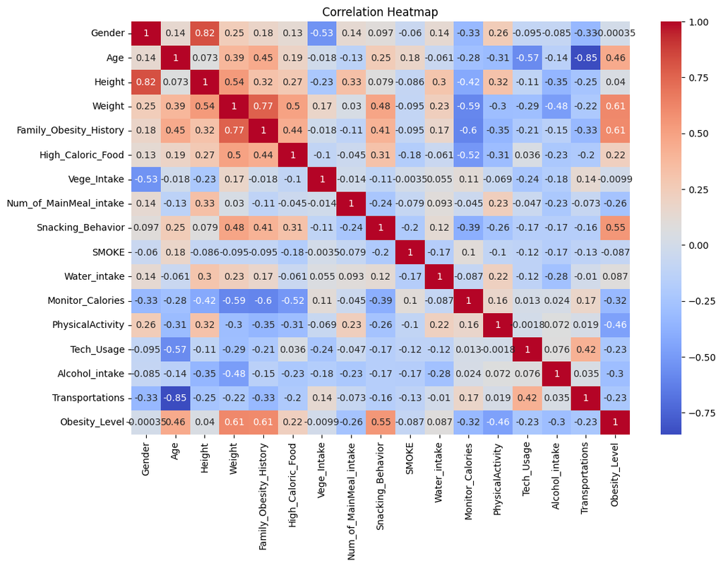

```python
plt.figure(figsize = (12, 8))
sns.heatmap(corr_matrix.corr(), annot = True, cmap='coolwarm')
plt.title("Correlation Heatmap")
plt.show()
```

## Splitting Features and Target Label

```python
X_train = df_train.drop('Obesity_Level', axis = 1)
X_test = df_test.drop('Obesity_Level', axis = 1)
y_train = df_train['Obesity_Level']
y_test = df_test['Obesity_Level']
```

```python
print('X_train.shape:', X_train.shape)
print('X_test.shape:', X_test.shape)
print('y_train.shape:', y_train.shape)
print('y_test.shape:', y_test.shape)
```

```
X_train.shape: (1565, 16)
X_test.shape: (522, 16)
y_train.shape: (1565,)
y_test.shape: (522,)
```

```python
X_train,X_test, y_train, y_test = train_test_split(X_train, y_train, test_size=0.2, random_state=42)
```

```python
scaler = StandardScaler()
```

```python
scaled_X_train = scaler.fit_transform(X_train)
scaled_X_test = scaler.transform(X_test)
```

Used the StandardScaler() to make sure all the columns ( features) are equally contributed into machine learning model in order to avoid the Bias of one feature.

## Model Training and Model Evaluation

**1. Logistic Regression**

creating simple logistic model

```python
log_model = LogisticRegression()
```

```python
log_model.fit(scaled_X_train, y_train)
```

```
LogisticRegression()
```

```python
y_pred1 = log_model.predict(scaled_X_test)
```

```python
confusion_matrix(y_test, y_pred1)
```

```
array([[33,  1,  0,  0,  0,  0,  0],
       [ 6, 35,  0,  0,  0,  3,  2],
       [ 0,  0, 50,  3,  2,  2,  1],
       [ 0,  0,  1, 46,  0,  0,  0],
       [ 0,  0,  0,  0, 47,  0,  0],
       [ 0,  4,  0,  0,  0, 33,  7],
       [ 0,  0,  2,  0,  0,  4, 31]])
```

```python
accuracy = accuracy_score(y_test, y_pred1)
accuracy
```

```
0.8785942492012779
```

```python
print(classification_report(y_test, y_pred1))
```

```
              precision    recall  f1-score   support

           0       0.85      0.97      0.90        34
           1       0.88      0.76      0.81        46
           2       0.94      0.86      0.90        58
           3       0.94      0.98      0.96        47
           4       0.96      1.00      0.98        47
           5       0.79      0.75      0.77        44
           6       0.76      0.84      0.79        37

    accuracy                           0.88       313
   macro avg       0.87      0.88      0.87       313
weighted avg       0.88      0.88      0.88       313
```

**2. Support Vector Machine**

creating support vector machine with linear for kernel and regularization parameter with 3.

```python
svc = SVC (kernel = 'linear', C=3)
svc.fit(X_train, y_train)
```

```
SVC(C=3, kernel='linear')
```

```python
y_pred2 = svc.predict(X_test)
```

```python
accuracy2 = accuracy_score(y_test, y_pred2)
accuracy2
```

```
0.9297124600638977
```

```python
print(classification_report(y_test, y_pred2))
```

```
              precision    recall  f1-score   support

           0       0.85      1.00      0.92        34
           1       0.93      0.80      0.86        46
           2       0.93      0.95      0.94        58
           3       0.96      1.00      0.98        47
           4       1.00      1.00      1.00        47
           5       0.91      0.89      0.90        44
           6       0.91      0.86      0.89        37

    accuracy                           0.93       313
   macro avg       0.93      0.93      0.93       313
weighted avg       0.93      0.93      0.93       313
```

**3. Decision Tree**

creating decision tree with entropy for criterion and max depth for 6.

```python
dt = DecisionTreeClassifier(criterion='entropy', max_depth=6)
dt.fit(X_train, y_train)
```

```
DecisionTreeClassifier(criterion='entropy', max_depth=6)
```

```python
y_pred3 = dt.predict(X_test)
```

```python
accuracy3 = accuracy_score(y_test, y_pred3)
accuracy3
```

```
0.9201277955271565
```

```python
print(classification_report(y_test, y_pred3))
```

```
              precision    recall  f1-score   support

           0       0.94      1.00      0.97        34
           1       0.97      0.83      0.89        46
           2       0.92      0.95      0.93        58
           3       1.00      0.94      0.97        47
           4       1.00      1.00      1.00        47
           5       0.82      0.84      0.83        44
           6       0.79      0.89      0.84        37

    accuracy                           0.92       313
   macro avg       0.92      0.92      0.92       313
weighted avg       0.92      0.92      0.92       313
```

## Conclusion

```python
table = PrettyTable()
```

```python
table.field_names = ['Model', 'Accuracy']
table.add_row(['Logistic Regression', 88])
table.add_row(['Support Vector Machine_SVM', 93])
table.add_row(['Decision Tree', 92])
```

```python
display('The result of models')
print(table)
```

```
'The result of models'
```

```
+----------------------------+----------+
|           Model            | Accuracy |
+----------------------------+----------+
|    Logistic Regression     |    88    |
| Support Vector Machine_SVM |    93    |
|       Decision Tree        |    92    |
+----------------------------+----------+
```

# Final Discussion

As 3 different models have been implemented and by comparing results by far Logistic Regression is with the lowest accuracy rate with 88%. The remaining other 2 models ( SVM and Decision tree)' accuracy are quite simliar with the 93% and 92% respectivitely. Despite the simliar accuray, I would recommed to use the SVM model because as per F1_score the SVM perform better in class 5 and 6 compared to the other models.